```r
# Remove the NA values
good_act <- activity[complete.cases(activity), ]
```

### Histogram of the total number of steps taken each day

For this part, first I will calculate the total number of steps taken each day and then create a histogram

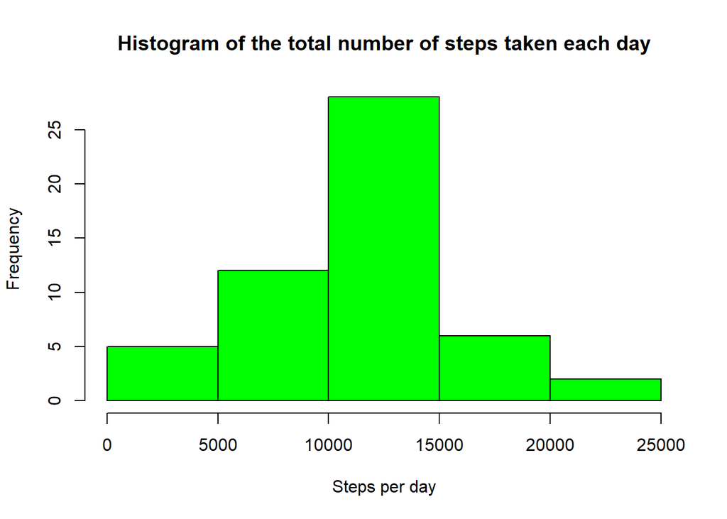

```r
# calculate the total number of steps taken each day
steps_per_day <- aggregate(steps ~ date, good_act,sum)
# create the histogram
hist(steps_per_day$steps, main = "Histogram of the total number of steps taken each day", col = "green", xlab = "Steps per day")
```

### calculate the mean and median number of steps taken each day

```r
# calculate the mean
mean(steps_per_day$steps)
```

```
## [1] 10766.19
```

```r
# calculate the median
median(steps_per_day$steps)
```

```
## [1] 10765
```

### Time series plot of the avarage number of the steps taken

1. Make a time series plot (i.e. type = “l”) of the 5-minute interval (x-axis) and the average number of steps taken, averaged across all days (y-axis)

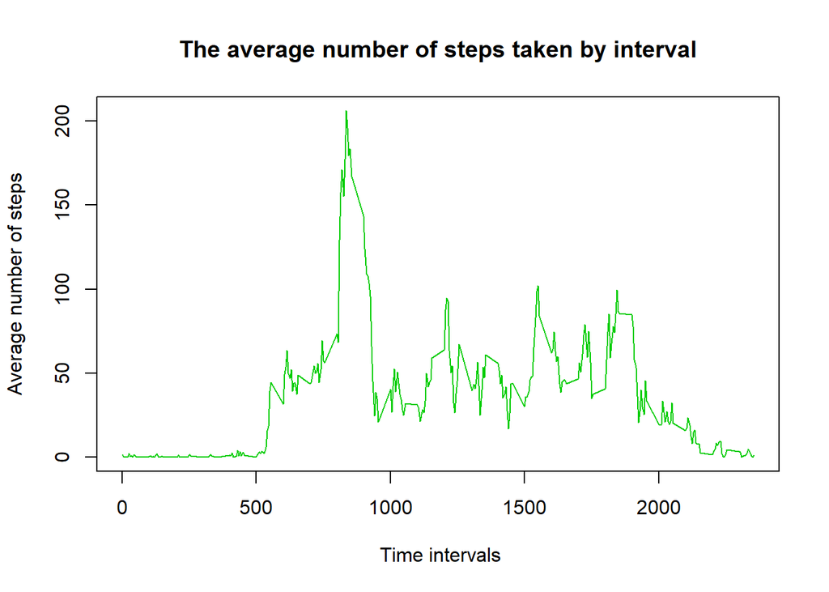

```r
# calculate average steps per interval for all days

avg_steps_per_interval <- aggregate(steps ~ interval, good_act, mean)

# plot the time series
plot(avg_steps_per_interval$interval, avg_steps_per_interval$steps, type='l', col=3, main="The average number of steps taken by interval", xlab=" Time intervals", ylab="Average number of steps")
```

```r
max_interval<- which.max(avg_steps_per_interval$steps)
avg_steps_per_interval[max_interval,]$interval
```

```
## [1] 835
```

### Code to describe and show a strategy for imputing missing data

1.Calculate and report the total number of missing values in the dataset (i.e. the total number of rows with NAs)

2.Devise a strategy for filling in all of the missing values in the dataset. The strategy does not need to be sophisticated. For example, you could use the mean/median for that day, or the mean for that 5-minute interval, etc.

3.Create a new dataset that is equal to the original dataset but with the missing data filled in.

```r
# Calculate the missing values
bad_act  <-activity[!complete.cases(activity),]
nrow(bad_act)
```

```
## [1] 2304
```

```r
# Loop through all the rows and find which step has NA in that row.Then identify the avg steps for that interval in avg_steps_per_interval and substitute the NA value with that value

for (i in 1:nrow(activity)) {
    if(is.na(activity$steps[i])) {
        val <- avg_steps_per_interval$steps[which(avg_steps_per_interval$interval == activity$interval[i])]
        activity$steps[i] <- val
    }
}
```

### Histogram of the total number of steps taken each day after values are imputed

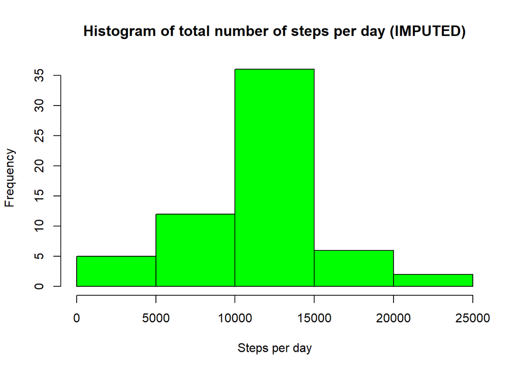

```r
# The steps per day with the imputed values
steps_per_day_impute <- aggregate(steps ~ date, activity, sum)
# Create a histogram
hist(steps_per_day_impute$steps, main = "Histogram of total number of steps per day (IMPUTED)", xlab = "Steps per day", col="green")
```

```r
# Calculate the mean
mean(steps_per_day_impute$steps)
```

```
## [1] 10766.19
```

```r
# calculate the median
median(steps_per_day_impute$steps)
```

```
## [1] 10766.19
```

```r
 week <- (activity$date)
 week <-weekdays(as.Date(week))
 class(week)
```

```
## [1] "character"
```

```r
 week <- as.factor(week)
 table(week)
```

```
## week
##    Friday    Monday  Saturday    Sunday  Thursday   Tuesday Wednesday
##       576       864      1152      1152       864      1152      1152
```

```r
 act <- as.Date(week, "%Y,%m,%d")
```